# Comcast_telecom_complaints

## Comcast Telecom Consumer Complaints

```python
import pandas as pd
import numpy as np
import matplotlib.pyplot as plt
```

```python
# Import data into Python environment.
comcast_complaints = pd.read_csv('Comcast_telecom_complaints_data.csv')
comcast_complaints
```

|  | Ticket # | Customer Complaint | Date | Date_month_year | Time | Received Via | City | State | Zip code | Status | Filing on Behalf of Someone |
| --- | --- | --- | --- | --- | --- | --- | --- | --- | --- | --- | --- |
| 0 | 250635 | Comcast Cable Internet Speeds | 22-04-15 | 22-Apr-15 | 3:53:50 PM | Customer Care Call | Abingdon | Maryland | 21009 | Closed | No |
| 1 | 223441 | Payment disappear - service got disconnected | 04-08-15 | 04-Aug-15 | 10:22:56 AM | Internet | Acworth | Georgia | 30102 | Closed | No |
| 2 | 242732 | Speed and Service | 18-04-15 | 18-Apr-15 | 9:55:47 AM | Internet | Acworth | Georgia | 30101 | Closed | Yes |
| 3 | 277946 | Comcast Imposed a New Usage Cap of 300GB that ... | 05-07-15 | 05-Jul-15 | 11:59:35 AM | Internet | Acworth | Georgia | 30101 | Open | Yes |
| 4 | 307175 | Comcast not working and no service to boot | 26-05-15 | 26-May-15 | 1:25:26 PM | Internet | Acworth | Georgia | 30101 | Solved | No |
| ... | ... | ... | ... | ... | ... | ... | ... | ... | ... | ... | ... |
| 2219 | 213550 | Service Availability | 04-02-15 | 04-Feb-15 | 9:13:18 AM | Customer Care Call | Youngstown | Florida | 32466 | Closed | No |
| 2220 | 318775 | Comcast Monthly Billing for Returned Modem | 06-02-15 | 06-Feb-15 | 1:24:39 PM | Customer Care Call | Ypsilanti | Michigan | 48197 | Solved | No |
| 2221 | 331188 | complaint about comcast | 06-09-15 | 06-Sep-15 | 5:28:41 PM | Internet | Ypsilanti | Michigan | 48197 | Solved | No |
| 2222 | 360489 | Extremely unsatisfied Comcast customer | 23-06-15 | 23-Jun-15 | 11:13:30 PM | Customer Care Call | Ypsilanti | Michigan | 48197 | Solved | No |
| 2223 | 363614 | Comcast, Ypsilanti MI Internet Speed | 24-06-15 | 24-Jun-15 | 10:28:33 PM | Customer Care Call | Ypsilanti | Michigan | 48198 | Open | Yes |

2224 rows × 11 columns

```python
# checking for any null values
comcast_complaints.isnull().sum()
```

```
Ticket #                       0
Customer Complaint             0
Date                           0
Date_month_year                0
Time                           0
Received Via                   0
City                           0
State                          0
Zip code                       0
Status                         0
Filing on Behalf of Someone    0
dtype: int64
```

```python
# viewing the column details and null values
comcast_complaints.info()
```

```
<class 'pandas.core.frame.DataFrame'>
RangeIndex: 2224 entries, 0 to 2223
Data columns (total 11 columns):
 #   Column                       Non-Null Count  Dtype
---  ------                       --------------  -----
 0   Ticket #                     2224 non-null   object
 1   Customer Complaint           2224 non-null   object
 2   Date                         2224 non-null   object
 3   Date_month_year              2224 non-null   object
 4   Time                         2224 non-null   object
 5   Received Via                 2224 non-null   object
 6   City                         2224 non-null   object
 7   State                        2224 non-null   object
 8   Zip code                     2224 non-null   int64
 9   Status                       2224 non-null   object
 10  Filing on Behalf of Someone  2224 non-null   object
dtypes: int64(1), object(10)
memory usage: 191.2+ KB
```

#### convert Date and Date_month_year columns data types from Object to datetime format`m

```python
comcast_complaints['Date'] = pd.to_datetime(comcast_complaints['Date'])
```

```python
comcast_complaints['Date_month_year'] = pd.to_datetime(comcast_complaints['Date_month_year'])
```

```python
comcast_complaints.info()
```

```
<class 'pandas.core.frame.DataFrame'>
RangeIndex: 2224 entries, 0 to 2223
Data columns (total 11 columns):
 #   Column                       Non-Null Count  Dtype
---  ------                       --------------  -----
 0   Ticket #                     2224 non-null   object
 1   Customer Complaint           2224 non-null   object
 2   Date                         2224 non-null   datetime64[ns]
 3   Date_month_year              2224 non-null   datetime64[ns]
 4   Time                         2224 non-null   object
 5   Received Via                 2224 non-null   object
 6   City                         2224 non-null   object
 7   State                        2224 non-null   object
 8   Zip code                     2224 non-null   int64
 9   Status                       2224 non-null   object
 10  Filing on Behalf of Someone  2224 non-null   object
dtypes: datetime64[ns](2), int64(1), object(8)
memory usage: 191.2+ KB
```

### Provide the trend chart for the number of complaints at monthly and daily granularity levels.

```python
# Create a new column Month which extracts month value from the Date_month_year column
comcast_complaints['Month'] = pd.DatetimeIndex(comcast_complaints['Date_month_year']).month
comcast_complaints
```

|  | Ticket # | Customer Complaint | Date | Date_month_year | Time | Received Via | City | State | Zip code | Status | Filing on Behalf of Someone | Month |
| --- | --- | --- | --- | --- | --- | --- | --- | --- | --- | --- | --- | --- |
| 0 | 250635 | Comcast Cable Internet Speeds | 2015-04-22 | 2015-04-22 | 3:53:50 PM | Customer Care Call | Abingdon | Maryland | 21009 | Closed | No | 4 |
| 1 | 223441 | Payment disappear - service got disconnected | 2015-04-08 | 2015-08-04 | 10:22:56 AM | Internet | Acworth | Georgia | 30102 | Closed | No | 8 |
| 2 | 242732 | Speed and Service | 2015-04-18 | 2015-04-18 | 9:55:47 AM | Internet | Acworth | Georgia | 30101 | Closed | Yes | 4 |
| 3 | 277946 | Comcast Imposed a New Usage Cap of 300GB that ... | 2015-05-07 | 2015-07-05 | 11:59:35 AM | Internet | Acworth | Georgia | 30101 | Open | Yes | 7 |
| 4 | 307175 | Comcast not working and no service to boot | 2015-05-26 | 2015-05-26 | 1:25:26 PM | Internet | Acworth | Georgia | 30101 | Solved | No | 5 |
| ... | ... | ... | ... | ... | ... | ... | ... | ... | ... | ... | ... | ... |
| 2219 | 213550 | Service Availability | 2015-04-02 | 2015-02-04 | 9:13:18 AM | Customer Care Call | Youngstown | Florida | 32466 | Closed | No | 2 |
| 2220 | 318775 | Comcast Monthly Billing for Returned Modem | 2015-06-02 | 2015-02-06 | 1:24:39 PM | Customer Care Call | Ypsilanti | Michigan | 48197 | Solved | No | 2 |
| 2221 | 331188 | complaint about comcast | 2015-06-09 | 2015-09-06 | 5:28:41 PM | Internet | Ypsilanti | Michigan | 48197 | Solved | No | 9 |
| 2222 | 360489 | Extremely unsatisfied Comcast customer | 2015-06-23 | 2015-06-23 | 11:13:30 PM | Customer Care Call | Ypsilanti | Michigan | 48197 | Solved | No | 6 |
| 2223 | 363614 | Comcast, Ypsilanti MI Internet Speed | 2015-06-24 | 2015-06-24 | 10:28:33 PM | Customer Care Call | Ypsilanti | Michigan | 48198 | Open | Yes | 6 |

2224 rows × 12 columns

```python
## group the number of complaints on monthly basis
comcast_monthly_complaints = comcast_complaints.groupby('Month')['Customer Complaint'].count().reset_index()
comcast_monthly_complaints
```

|  | Month | Customer Complaint |
| --- | --- | --- |
| 0 | 1 | 55 |
| 1 | 2 | 59 |
| 2 | 3 | 45 |
| 3 | 4 | 375 |
| 4 | 5 | 317 |
| 5 | 6 | 1046 |
| 6 | 7 | 49 |
| 7 | 8 | 67 |
| 8 | 9 | 55 |
| 9 | 10 | 53 |
| 10 | 11 | 38 |
| 11 | 12 | 65 |

```python
comcast_monthly_complaints['Month'].replace({1:'JAN',2:'FEB',3:'MAR',4:'APR',
                                                                             5:'MAY',6:'JUN',7:'JUL',8:'AUG',9:'SEP',
                                                                              10:'OCT',11:'NOV',12:'DEC'},inplace=True)
comcast_monthly_complaints
```

|  | Month | Customer Complaint |
| --- | --- | --- |
| 0 | JAN | 55 |
| 1 | FEB | 59 |
| 2 | MAR | 45 |
| 3 | APR | 375 |
| 4 | MAY | 317 |
| 5 | JUN | 1046 |
| 6 | JUL | 49 |
| 7 | AUG | 67 |
| 8 | SEP | 55 |
| 9 | OCT | 53 |
| 10 | NOV | 38 |
| 11 | DEC | 65 |

```python
## group the number of complaints on daily basis
comcast_daily_complaints = comcast_complaints.groupby('Date_month_year')['Customer Complaint'].count().reset_index()
comcast_daily_complaints.sort_values(by='Date_month_year')
comcast_daily_complaints
```

|  | Date_month_year | Customer Complaint |
| --- | --- | --- |
| 0 | 2015-01-04 | 18 |
| 1 | 2015-01-05 | 12 |
| 2 | 2015-01-06 | 25 |
| 3 | 2015-02-04 | 27 |
| 4 | 2015-02-05 | 7 |
| ... | ... | ... |
| 86 | 2015-11-05 | 12 |
| 87 | 2015-11-06 | 21 |
| 88 | 2015-12-04 | 15 |
| 89 | 2015-12-05 | 7 |
| 90 | 2015-12-06 | 43 |

91 rows × 2 columns

### Trend chart

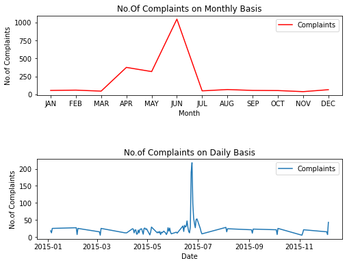

```python
## creating trend charts to plot number of complaints at monthly and daily granularity levels using subplots
plt.figure(figsize=(8,6))
plt.subplots_adjust(hspace = 0.8)
plt.subplot(2,1,1)
plt.plot(comcast_monthly_complaints['Month'],comcast_monthly_complaints['Customer Complaint'],color='r',label='Complaints')
plt.title('No.Of Complaints on Monthly Basis')
plt.xlabel('Month')
plt.ylabel('No.of Complaints')
plt.subplots_adjust()
plt.legend()

plt.subplot(2,1,2)
plt.plot(comcast_daily_complaints['Date_month_year'],comcast_daily_complaints['Customer Complaint'],label='Complaints')
plt.title('No.of Complaints on Daily Basis')
plt.xlabel('Date')
plt.ylabel('No.of Complaints')
plt.legend()
plt.show()
```

```python
# create a new column Complaint Type consists of 10 different values -> assigned based on the complaint type
comcast_complaints['Complaint Type'] = np.where((comcast_complaints['Customer Complaint'].str.contains('Internet',case=False)),"Internet",
                                      np.where(comcast_complaints['Customer Complaint'].str.contains('Bill',case=False),"Billing",
                                      np.where(comcast_complaints['Customer Complaint'].str.contains('Charge',case=False),"Charge",
                                      np.where(comcast_complaints['Customer Complaint'].str.contains('Service',case=False),"Service",
                                      np.where(comcast_complaints['Customer Complaint'].str.contains('refund',case=False),"Refund",
                                      np.where(comcast_complaints['Customer Complaint'].str.contains('Data Cap',case=False),"Data Caps",
                                      np.where(comcast_complaints['Customer Complaint'].str.contains('Email',case=False), "Email",
                                        np.where(comcast_complaints['Customer Complaint'].str.contains('Comcast',case=False), "Comcast",
                                         np.where(comcast_complaints['Customer Complaint'].str.contains('Speed',case=False), "Speed",
                                                 "Other"))
                                        )))))))
```

```python
comcast_complaints
```

|  | Ticket # | Customer Complaint | Date | Date_month_year | Time | Received Via | City | State | Zip code | Status | Filing on Behalf of Someone | Month | Complaint Type |
| --- | --- | --- | --- | --- | --- | --- | --- | --- | --- | --- | --- | --- | --- |
| 0 | 250635 | Comcast Cable Internet Speeds | 2015-04-22 | 2015-04-22 | 3:53:50 PM | Customer Care Call | Abingdon | Maryland | 21009 | Closed | No | 4 | Internet |
| 1 | 223441 | Payment disappear - service got disconnected | 2015-04-08 | 2015-08-04 | 10:22:56 AM | Internet | Acworth | Georgia | 30102 | Closed | No | 8 | Service |
| 2 | 242732 | Speed and Service | 2015-04-18 | 2015-04-18 | 9:55:47 AM | Internet | Acworth | Georgia | 30101 | Closed | Yes | 4 | Service |
| 3 | 277946 | Comcast Imposed a New Usage Cap of 300GB that ... | 2015-05-07 | 2015-07-05 | 11:59:35 AM | Internet | Acworth | Georgia | 30101 | Open | Yes | 7 | Comcast |
| 4 | 307175 | Comcast not working and no service to boot | 2015-05-26 | 2015-05-26 | 1:25:26 PM | Internet | Acworth | Georgia | 30101 | Solved | No | 5 | Service |
| ... | ... | ... | ... | ... | ... | ... | ... | ... | ... | ... | ... | ... | ... |
| 2219 | 213550 | Service Availability | 2015-04-02 | 2015-02-04 | 9:13:18 AM | Customer Care Call | Youngstown | Florida | 32466 | Closed | No | 2 | Service |
| 2220 | 318775 | Comcast Monthly Billing for Returned Modem | 2015-06-02 | 2015-02-06 | 1:24:39 PM | Customer Care Call | Ypsilanti | Michigan | 48197 | Solved | No | 2 | Billing |
| 2221 | 331188 | complaint about comcast | 2015-06-09 | 2015-09-06 | 5:28:41 PM | Internet | Ypsilanti | Michigan | 48197 | Solved | No | 9 | Comcast |
| 2222 | 360489 | Extremely unsatisfied Comcast customer | 2015-06-23 | 2015-06-23 | 11:13:30 PM | Customer Care Call | Ypsilanti | Michigan | 48197 | Solved | No | 6 | Comcast |
| 2223 | 363614 | Comcast, Ypsilanti MI Internet Speed | 2015-06-24 | 2015-06-24 | 10:28:33 PM | Customer Care Call | Ypsilanti | Michigan | 48198 | Open | Yes | 6 | Internet |

2224 rows × 13 columns

### Provide a table with the frequency of complaint types.

```python
comcast_complaints_frequency = comcast_complaints.groupby('Complaint Type')['Customer Complaint'].count().reset_index()
print(comcast_complaints_frequency)
```

```
  Complaint Type  Customer Complaint
0        Billing                 333
1         Charge                 110
2        Comcast                 529
3      Data Caps                 133
4          Email                  10
5       Internet                 532
6          Other                 259
7         Refund                  10
8        Service                 270
9          Speed                  38
```

### Which complaint types are maximum i.e., around internet, network issues, or across any other domains.

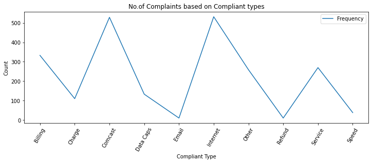

```python
plt.figure(figsize=(12,4))
plt.plot(comcast_complaints_frequency['Complaint Type'],comcast_complaints_frequency['Customer Complaint'],label='Frequency')
plt.xlabel('Compliant Type')
plt.ylabel('Count')
plt.xticks(rotation=60)
plt.legend()
plt.title('No.of Complaints based on Compliant types')
plt.show()
```

### From the above comcast_complaints_frequency dataframe and line graph it is clear that - Internet Complaint type is maximum

### Create a new categorical variable with value as Open and Closed. Open & Pending is to be categorized as Open and Closed & Solved is to be categorized as Closed.

```python
## create new column named Open/Closed having values Open/Closed as per the requirement
comcast_complaints['Open/Closed'] = np.where(comcast_complaints['Status'].str.contains('Open') | comcast_complaints['Status'].str.contains('Pending'),"Open","Closed")
```

```python
comcast_complaints
```

|  | Ticket # | Customer Complaint | Date | Date_month_year | Time | Received Via | City | State | Zip code | Status | Filing on Behalf of Someone | Month | Complaint Type | Open/Closed |
| --- | --- | --- | --- | --- | --- | --- | --- | --- | --- | --- | --- | --- | --- | --- |
| 0 | 250635 | Comcast Cable Internet Speeds | 2015-04-22 | 2015-04-22 | 3:53:50 PM | Customer Care Call | Abingdon | Maryland | 21009 | Closed | No | 4 | Internet | Closed |
| 1 | 223441 | Payment disappear - service got disconnected | 2015-04-08 | 2015-08-04 | 10:22:56 AM | Internet | Acworth | Georgia | 30102 | Closed | No | 8 | Service | Closed |
| 2 | 242732 | Speed and Service | 2015-04-18 | 2015-04-18 | 9:55:47 AM | Internet | Acworth | Georgia | 30101 | Closed | Yes | 4 | Service | Closed |
| 3 | 277946 | Comcast Imposed a New Usage Cap of 300GB that ... | 2015-05-07 | 2015-07-05 | 11:59:35 AM | Internet | Acworth | Georgia | 30101 | Open | Yes | 7 | Comcast | Open |
| 4 | 307175 | Comcast not working and no service to boot | 2015-05-26 | 2015-05-26 | 1:25:26 PM | Internet | Acworth | Georgia | 30101 | Solved | No | 5 | Service | Closed |
| ... | ... | ... | ... | ... | ... | ... | ... | ... | ... | ... | ... | ... | ... | ... |
| 2219 | 213550 | Service Availability | 2015-04-02 | 2015-02-04 | 9:13:18 AM | Customer Care Call | Youngstown | Florida | 32466 | Closed | No | 2 | Service | Closed |
| 2220 | 318775 | Comcast Monthly Billing for Returned Modem | 2015-06-02 | 2015-02-06 | 1:24:39 PM | Customer Care Call | Ypsilanti | Michigan | 48197 | Solved | No | 2 | Billing | Closed |
| 2221 | 331188 | complaint about comcast | 2015-06-09 | 2015-09-06 | 5:28:41 PM | Internet | Ypsilanti | Michigan | 48197 | Solved | No | 9 | Comcast | Closed |
| 2222 | 360489 | Extremely unsatisfied Comcast customer | 2015-06-23 | 2015-06-23 | 11:13:30 PM | Customer Care Call | Ypsilanti | Michigan | 48197 | Solved | No | 6 | Comcast | Closed |
| 2223 | 363614 | Comcast, Ypsilanti MI Internet Speed | 2015-06-24 | 2015-06-24 | 10:28:33 PM | Customer Care Call | Ypsilanti | Michigan | 48198 | Open | Yes | 6 | Internet | Open |

2224 rows × 14 columns

### Provide state wise status of complaints in a stacked bar chart. Use the categorized variable from Q3

#### Plot stacked bar chart for state wise status of complaints (Open/Closed)

```python
## splitting count of Open and Closed complaints based on State
## since identified some missing values fill them with 0
comcast_state_complaints = comcast_complaints.groupby(['State','Open/Closed']).size().unstack().fillna(0)
comcast_state_complaints
```

| Open/Closed State | Closed | Open |
| --- | --- | --- |
| Alabama | 17.0 | 9.0 |
| Arizona | 14.0 | 6.0 |
| Arkansas | 6.0 | 0.0 |
| California | 159.0 | 61.0 |
| Colorado | 58.0 | 22.0 |
| Connecticut | 9.0 | 3.0 |
| Delaware | 8.0 | 4.0 |
| District Of Columbia | 14.0 | 2.0 |
| District of Columbia | 1.0 | 0.0 |
| Florida | 201.0 | 39.0 |
| Georgia | 208.0 | 80.0 |
| Illinois | 135.0 | 29.0 |
| Indiana | 50.0 | 9.0 |
| Iowa | 1.0 | 0.0 |
| Kansas | 1.0 | 1.0 |
| Kentucky | 4.0 | 3.0 |
| Louisiana | 12.0 | 1.0 |
| Maine | 3.0 | 2.0 |
| Maryland | 63.0 | 15.0 |
| Massachusetts | 50.0 | 11.0 |
| Michigan | 92.0 | 23.0 |
| Minnesota | 29.0 | 4.0 |
| Mississippi | 23.0 | 16.0 |
| Missouri | 3.0 | 1.0 |
| Montana | 1.0 | 0.0 |
| Nevada | 1.0 | 0.0 |
| New Hampshire | 8.0 | 4.0 |
| New Jersey | 56.0 | 19.0 |
| New Mexico | 11.0 | 4.0 |
| New York | 6.0 | 0.0 |
| North Carolina | 3.0 | 0.0 |
| Ohio | 3.0 | 0.0 |
| Oregon | 36.0 | 13.0 |
| Pennsylvania | 110.0 | 20.0 |
| Rhode Island | 1.0 | 0.0 |
| South Carolina | 15.0 | 3.0 |
| Tennessee | 96.0 | 47.0 |
| Texas | 49.0 | 22.0 |
| Utah | 16.0 | 6.0 |
| Vermont | 2.0 | 1.0 |
| Virginia | 49.0 | 11.0 |
| Washington | 75.0 | 23.0 |
| West Virginia | 8.0 | 3.0 |

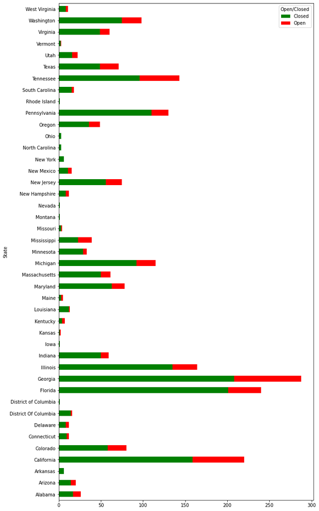

```python
# plot stacked bar chart for State and Open Closed complaints
comcast_state_complaints.plot.barh(stacked=True,figsize=(10,20),color={'Closed':'g','Open':'r'})
```

#### Plot stacked bar chart for State wise Type of complaints

```python
comcast_state_complaint_type = comcast_complaints.groupby(['State','Complaint Type']).size().unstack().fillna(0)
comcast_state_complaint_type
```

| Complaint Type State | Billing | Charge | Comcast | Data Caps | Email | Internet | Other | Refund | Service | Speed |
| --- | --- | --- | --- | --- | --- | --- | --- | --- | --- | --- |
| Alabama | 0.0 | 3.0 | 2.0 | 8.0 | 0.0 | 0.0 | 5.0 | 1.0 | 6.0 | 1.0 |
| Arizona | 3.0 | 0.0 | 2.0 | 6.0 | 0.0 | 6.0 | 2.0 | 0.0 | 1.0 | 0.0 |
| Arkansas | 0.0 | 0.0 | 2.0 | 0.0 | 0.0 | 4.0 | 0.0 | 0.0 | 0.0 | 0.0 |
| California | 31.0 | 17.0 | 52.0 | 0.0 | 2.0 | 59.0 | 29.0 | 3.0 | 20.0 | 7.0 |
| Colorado | 13.0 | 1.0 | 20.0 | 1.0 | 0.0 | 18.0 | 17.0 | 0.0 | 8.0 | 2.0 |
| Connecticut | 0.0 | 0.0 | 1.0 | 0.0 | 0.0 | 6.0 | 0.0 | 0.0 | 5.0 | 0.0 |
| Delaware | 1.0 | 1.0 | 3.0 | 0.0 | 0.0 | 3.0 | 2.0 | 0.0 | 2.0 | 0.0 |
| District Of Columbia | 6.0 | 0.0 | 2.0 | 0.0 | 0.0 | 3.0 | 4.0 | 0.0 | 1.0 | 0.0 |
| District of Columbia | 0.0 | 0.0 | 0.0 | 0.0 | 0.0 | 1.0 | 0.0 | 0.0 | 0.0 | 0.0 |
| Florida | 46.0 | 11.0 | 56.0 | 0.0 | 2.0 | 63.0 | 29.0 | 0.0 | 32.0 | 1.0 |
| Georgia | 33.0 | 17.0 | 64.0 | 62.0 | 0.0 | 41.0 | 22.0 | 2.0 | 45.0 | 2.0 |
| Illinois | 30.0 | 7.0 | 47.0 | 1.0 | 1.0 | 40.0 | 20.0 | 0.0 | 15.0 | 3.0 |
| Indiana | 11.0 | 3.0 | 18.0 | 0.0 | 0.0 | 12.0 | 7.0 | 0.0 | 8.0 | 0.0 |
| Iowa | 0.0 | 1.0 | 0.0 | 0.0 | 0.0 | 0.0 | 0.0 | 0.0 | 0.0 | 0.0 |
| Kansas | 1.0 | 0.0 | 1.0 | 0.0 | 0.0 | 0.0 | 0.0 | 0.0 | 0.0 | 0.0 |
| Kentucky | 1.0 | 0.0 | 1.0 | 2.0 | 0.0 | 2.0 | 1.0 | 0.0 | 0.0 | 0.0 |
| Louisiana | 3.0 | 0.0 | 2.0 | 2.0 | 0.0 | 3.0 | 3.0 | 0.0 | 0.0 | 0.0 |
| Maine | 0.0 | 0.0 | 0.0 | 1.0 | 0.0 | 2.0 | 2.0 | 0.0 | 0.0 | 0.0 |
| Maryland | 11.0 | 4.0 | 19.0 | 0.0 | 0.0 | 20.0 | 13.0 | 1.0 | 10.0 | 0.0 |
| Massachusetts | 10.0 | 0.0 | 15.0 | 0.0 | 1.0 | 21.0 | 8.0 | 0.0 | 4.0 | 2.0 |
| Michigan | 28.0 | 5.0 | 25.0 | 1.0 | 0.0 | 34.0 | 10.0 | 0.0 | 10.0 | 2.0 |
| Minnesota | 6.0 | 2.0 | 8.0 | 1.0 | 0.0 | 8.0 | 5.0 | 1.0 | 2.0 | 0.0 |
| Mississippi | 4.0 | 5.0 | 7.0 | 8.0 | 0.0 | 7.0 | 6.0 | 0.0 | 2.0 | 0.0 |
| Missouri | 0.0 | 1.0 | 1.0 | 0.0 | 0.0 | 1.0 | 0.0 | 0.0 | 1.0 | 0.0 |
| Montana | 0.0 | 0.0 | 1.0 | 0.0 | 0.0 | 0.0 | 0.0 | 0.0 | 0.0 | 0.0 |
| Nevada | 0.0 | 0.0 | 1.0 | 0.0 | 0.0 | 0.0 | 0.0 | 0.0 | 0.0 | 0.0 |
| New Hampshire | 2.0 | 2.0 | 2.0 | 0.0 | 0.0 | 4.0 | 1.0 | 0.0 | 1.0 | 0.0 |
| New Jersey | 14.0 | 2.0 | 19.0 | 0.0 | 0.0 | 19.0 | 10.0 | 0.0 | 9.0 | 2.0 |
| New Mexico | 2.0 | 0.0 | 4.0 | 0.0 | 1.0 | 7.0 | 0.0 | 0.0 | 1.0 | 0.0 |
| New York | 1.0 | 0.0 | 1.0 | 0.0 | 0.0 | 2.0 | 1.0 | 0.0 | 1.0 | 0.0 |
| North Carolina | 0.0 | 0.0 | 1.0 | 0.0 | 0.0 | 2.0 | 0.0 | 0.0 | 0.0 | 0.0 |
| Ohio | 1.0 | 0.0 | 0.0 | 0.0 | 1.0 | 1.0 | 0.0 | 0.0 | 0.0 | 0.0 |
| Oregon | 6.0 | 5.0 | 13.0 | 0.0 | 0.0 | 11.0 | 3.0 | 0.0 | 9.0 | 2.0 |
| Pennsylvania | 15.0 | 2.0 | 36.0 | 0.0 | 1.0 | 37.0 | 13.0 | 0.0 | 23.0 | 3.0 |
| Rhode Island | 0.0 | 0.0 | 1.0 | 0.0 | 0.0 | 0.0 | 0.0 | 0.0 | 0.0 | 0.0 |
| South Carolina | 6.0 | 2.0 | 1.0 | 4.0 | 0.0 | 3.0 | 1.0 | 0.0 | 1.0 | 0.0 |
| Tennessee | 7.0 | 9.0 | 39.0 | 36.0 | 0.0 | 23.0 | 15.0 | 1.0 | 11.0 | 2.0 |
| Texas | 14.0 | 4.0 | 12.0 | 0.0 | 0.0 | 17.0 | 8.0 | 0.0 | 14.0 | 2.0 |
| Utah | 5.0 | 1.0 | 4.0 | 0.0 | 1.0 | 6.0 | 1.0 | 0.0 | 2.0 | 2.0 |
| Vermont | 0.0 | 0.0 | 0.0 | 0.0 | 0.0 | 2.0 | 0.0 | 1.0 | 0.0 | 0.0 |
| Virginia | 4.0 | 2.0 | 22.0 | 0.0 | 0.0 | 13.0 | 6.0 | 0.0 | 10.0 | 3.0 |
| Washington | 17.0 | 3.0 | 19.0 | 0.0 | 0.0 | 29.0 | 15.0 | 0.0 | 13.0 | 2.0 |
| West Virginia | 1.0 | 0.0 | 5.0 | 0.0 | 0.0 | 2.0 | 0.0 | 0.0 | 3.0 | 0.0 |

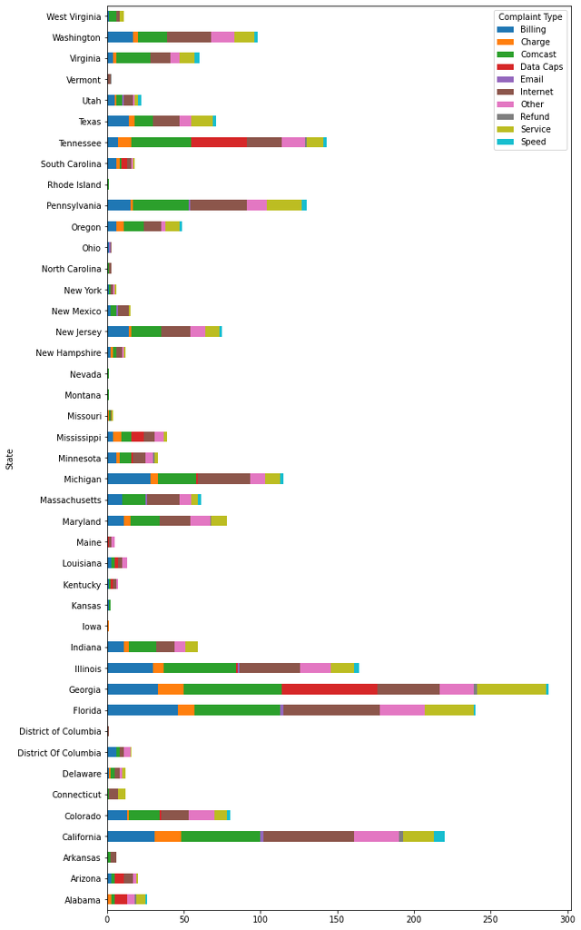

```python
# plot stacked bar chart for State and different complaint types
comcast_state_complaint_type.plot.barh(stacked=True,figsize=(10,20))
```

### Which state has the maximum complaints

```python
# create a dataframe with total no.of complaints from each state
comcast_max_complaints = comcast_complaints.groupby('State')['Customer Complaint'].count().reset_index()
comcast_max_complaints
```

|  | State | Customer Complaint |
| --- | --- | --- |
| 0 | Alabama | 26 |
| 1 | Arizona | 20 |
| 2 | Arkansas | 6 |
| 3 | California | 220 |
| 4 | Colorado | 80 |
| 5 | Connecticut | 12 |
| 6 | Delaware | 12 |
| 7 | District Of Columbia | 16 |
| 8 | District of Columbia | 1 |
| 9 | Florida | 240 |
| 10 | Georgia | 288 |
| 11 | Illinois | 164 |
| 12 | Indiana | 59 |
| 13 | Iowa | 1 |
| 14 | Kansas | 2 |
| 15 | Kentucky | 7 |
| 16 | Louisiana | 13 |
| 17 | Maine | 5 |
| 18 | Maryland | 78 |
| 19 | Massachusetts | 61 |
| 20 | Michigan | 115 |
| 21 | Minnesota | 33 |
| 22 | Mississippi | 39 |
| 23 | Missouri | 4 |
| 24 | Montana | 1 |
| 25 | Nevada | 1 |
| 26 | New Hampshire | 12 |
| 27 | New Jersey | 75 |
| 28 | New Mexico | 15 |
| 29 | New York | 6 |
| 30 | North Carolina | 3 |
| 31 | Ohio | 3 |
| 32 | Oregon | 49 |
| 33 | Pennsylvania | 130 |
| 34 | Rhode Island | 1 |
| 35 | South Carolina | 18 |
| 36 | Tennessee | 143 |
| 37 | Texas | 71 |
| 38 | Utah | 22 |
| 39 | Vermont | 3 |
| 40 | Virginia | 60 |
| 41 | Washington | 98 |
| 42 | West Virginia | 11 |

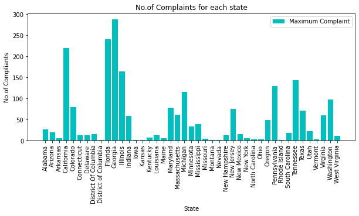

```python
## plot a bar chart to identify state with maximum compliants
plt.figure(figsize=(10,4))
plt.bar(comcast_max_complaints['State'],comcast_max_complaints['Customer Complaint'],label='Maximum Complaint',color='c')
plt.xlabel('State')
plt.ylabel('No.of Compliants')
plt.xticks(rotation=90)
plt.legend()
plt.title('No.of Complaints for each state')
plt.show()
```

### Georgia is having maximum number of complaints - 288

### Which state has the highest percentage of unresolved complaints

```python
## finding the state wise percentage of unresolved compliants(compliant status - open) and sorting it in descending order
comcast_state_complaints['Percentage'] = (comcast_state_complaints['Open']/comcast_state_complaints['Open'].sum())*100
comcast_state_complaints.sort_values('Percentage',ascending=False)
```

| Open/Closed State | Closed | Open | Percentage |
| --- | --- | --- | --- |
| Georgia | 208.0 | 80.0 | 15.473888 |
| California | 159.0 | 61.0 | 11.798839 |
| Tennessee | 96.0 | 47.0 | 9.090909 |
| Florida | 201.0 | 39.0 | 7.543520 |
| Illinois | 135.0 | 29.0 | 5.609284 |
| Washington | 75.0 | 23.0 | 4.448743 |
| Michigan | 92.0 | 23.0 | 4.448743 |
| Colorado | 58.0 | 22.0 | 4.255319 |
| Texas | 49.0 | 22.0 | 4.255319 |
| Pennsylvania | 110.0 | 20.0 | 3.868472 |
| New Jersey | 56.0 | 19.0 | 3.675048 |
| Mississippi | 23.0 | 16.0 | 3.094778 |
| Maryland | 63.0 | 15.0 | 2.901354 |
| Oregon | 36.0 | 13.0 | 2.514507 |
| Virginia | 49.0 | 11.0 | 2.127660 |
| Massachusetts | 50.0 | 11.0 | 2.127660 |
| Alabama | 17.0 | 9.0 | 1.740812 |
| Indiana | 50.0 | 9.0 | 1.740812 |
| Utah | 16.0 | 6.0 | 1.160542 |
| Arizona | 14.0 | 6.0 | 1.160542 |
| New Hampshire | 8.0 | 4.0 | 0.773694 |
| New Mexico | 11.0 | 4.0 | 0.773694 |
| Minnesota | 29.0 | 4.0 | 0.773694 |
| Delaware | 8.0 | 4.0 | 0.773694 |
| West Virginia | 8.0 | 3.0 | 0.580271 |
| Connecticut | 9.0 | 3.0 | 0.580271 |
| Kentucky | 4.0 | 3.0 | 0.580271 |
| South Carolina | 15.0 | 3.0 | 0.580271 |
| Maine | 3.0 | 2.0 | 0.386847 |
| District Of Columbia | 14.0 | 2.0 | 0.386847 |
| Kansas | 1.0 | 1.0 | 0.193424 |
| Vermont | 2.0 | 1.0 | 0.193424 |
| Missouri | 3.0 | 1.0 | 0.193424 |
| Louisiana | 12.0 | 1.0 | 0.193424 |
| Montana | 1.0 | 0.0 | 0.000000 |
| Rhode Island | 1.0 | 0.0 | 0.000000 |
| Ohio | 3.0 | 0.0 | 0.000000 |
| District of Columbia | 1.0 | 0.0 | 0.000000 |
| North Carolina | 3.0 | 0.0 | 0.000000 |
| New York | 6.0 | 0.0 | 0.000000 |
| Nevada | 1.0 | 0.0 | 0.000000 |
| Arkansas | 6.0 | 0.0 | 0.000000 |
| Iowa | 1.0 | 0.0 | 0.000000 |

#### From the above observation - Georgia is having the highest percentage of unresolved complaints

### Provide the percentage of complaints resolved till date, which were received through the Internet and customer care calls.

```python
# In the given data set check whether any record is of future dates
from datetime import date
np.where(comcast_complaints['Date_month_year']>date.today().strftime('%Y-%m-%d'))
```

```
(array([], dtype=int64),)
```

```python
### Group the comcast_complaints dataframe based on Received Via and Open/Closed Columns
comcast_resolved_complaints = comcast_complaints.groupby(['Received Via','Open/Closed']).size().unstack()
resolved_compliants = comcast_resolved_complaints['Closed']/comcast_resolved_complaints['Closed'].sum()*100
resolved_compliants
```

```
Received Via
Customer Care Call    50.615114
Internet              49.384886
Name: Closed, dtype: float64
```

```python
resolved_compliants.round()
```

```
Received Via
Customer Care Call    51.0
Internet              49.0
Name: Closed, dtype: float64
```

#### 51 percentage of Customer Care Call complaints and 49 percentage of Internet complaints resolved till date